# ePGD-ABA (2020-21) | Finance Elective | Professor Vineet Virmani | Credit Risk Assignment

Name:Arimitra Maiti, Email:aba20arimitram@iima.ac.in, Student ID : 6820017

5/5/2021

## Logit and Probit: Estimating probability of default

The data used in this assignment has been provided explicitly by the faculty and research associate team which constitutes Professor **Vineet** **Virmani**, Ms. **Venus** **Rais** and Mr. **Sathish** **LM**.

#### The bad loans dataset looks like this:

| Default | Amount | Loan_due | Home_value | Reason | Job | Years_Job | Bad_reports | Bad_loans | Loan_age | Inquiries | Existing_loans | Debt_income |
| --- | --- | --- | --- | --- | --- | --- | --- | --- | --- | --- | --- | --- |
| 1 | 1100 | 25860 | 39025 | HomeImp | Other | 10.5 | 0 | 0 | 94.36667 | 1 | 9 | NA |
| 1 | 1300 | 70053 | 68400 | HomeImp | Other | 7.0 | 0 | 2 | 121.83333 | 0 | 14 | NA |
| 1 | 1500 | 13500 | 16700 | HomeImp | Other | 4.0 | 0 | 0 | 149.46667 | 1 | 10 | NA |
| 1 | 1500 | NA | NA |  |  | NA | NA | NA | NA | NA | NA | NA |
| 0 | 1700 | 97800 | 112000 | HomeImp | Office | 3.0 | 0 | 0 | 93.33333 | 0 | 14 | NA |

#### When we summarize the dataset it looks as follows:

Data Frame Summary

data

**Dimensions**: 5960 x 13  
**Duplicates**: 0

| **No** | **Variable** | **Stats / Values** | **Freqs (% of Valid)** | **Graph** | **Valid** | **Missing** |
| --- | --- | --- | --- | --- | --- | --- |
| 1 | Default [integer] | Min : 0 Mean : 0.2 Max : 1 | 0 : 4771 ( 80.1% ) 1 : 1189 ( 19.9% ) |  | 5960 (100.0%) | 0 (0.0%) |
| 2 | Amount [integer] | Mean (sd) : 18608 (11207.5) min < med < max: 1100 < 16300 < 89900 IQR (CV) : 12200 (0.6) | 540 distinct values |  | 5960 (100.0%) | 0 (0.0%) |
| 3 | Loan_due [numeric] | Mean (sd) : 73760.8 (44457.6) min < med < max: 2063 < 65019 < 399550 IQR (CV) : 45212 (0.6) | 5053 distinct values |  | 5442 (91.3%) | 518 (8.7%) |
| 4 | Home_value [numeric] | Mean (sd) : 101776 (57385.8) min < med < max: 8000 < 89235.5 < 855909 IQR (CV) : 53748.8 (0.6) | 5381 distinct values |  | 5848 (98.1%) | 112 (1.9%) |
| 5 | Reason [character] | 1. (Empty string) 2. DebtCon 3. HomeImp | 252 ( 4.2% ) 3928 ( 65.9% ) 1780 ( 29.9% ) |  | 5960 (100.0%) | 0 (0.0%) |
| 6 | Job [character] | 1. (Empty string) 2. Mgr 3. Office 4. Other 5. ProfExe 6. Sales 7. Self | 279 ( 4.7% ) 767 ( 12.9% ) 948 ( 15.9% ) 2388 ( 40.1% ) 1276 ( 21.4% ) 109 ( 1.8% ) 193 ( 3.2% ) |  | 5960 (100.0%) | 0 (0.0%) |
| 7 | Years_Job [numeric] | Mean (sd) : 8.9 (7.6) min < med < max: 0 < 7 < 41 IQR (CV) : 10 (0.8) | 99 distinct values |  | 5445 (91.4%) | 515 (8.6%) |
| 8 | Bad_reports [integer] | Mean (sd) : 0.3 (0.8) min < med < max: 0 < 0 < 10 IQR (CV) : 0 (3.3) | 11 distinct values |  | 5252 (88.1%) | 708 (11.9%) |
| 9 | Bad_loans [integer] | Mean (sd) : 0.4 (1.1) min < med < max: 0 < 0 < 15 IQR (CV) : 0 (2.5) | 14 distinct values |  | 5380 (90.3%) | 580 (9.7%) |
| 10 | Loan_age [numeric] | Mean (sd) : 179.8 (85.8) min < med < max: 0 < 173.5 < 1168.2 IQR (CV) : 116.4 (0.5) | 5314 distinct values |  | 5652 (94.8%) | 308 (5.2%) |
| 11 | Inquiries [integer] | Mean (sd) : 1.2 (1.7) min < med < max: 0 < 1 < 17 IQR (CV) : 2 (1.5) | 16 distinct values |  | 5450 (91.4%) | 510 (8.6%) |
| 12 | Existing_loans [integer] | Mean (sd) : 21.3 (10.1) min < med < max: 0 < 20 < 71 IQR (CV) : 11 (0.5) | 62 distinct values |  | 5738 (96.3%) | 222 (3.7%) |
| 13 | Debt_income [numeric] | Mean (sd) : 33.8 (8.6) min < med < max: 0.5 < 34.8 < 203.3 IQR (CV) : 9.9 (0.3) | 4693 distinct values |  | 4693 (78.7%) | 1267 (21.3%) |

Generated by summarytools 0.9.9 ([R](https://www.r-project.org/) version 4.0.3)  
2021-05-06

We observe although there are no missing values in the target variable **Default**, yet there are missing values in quite a few explanatory attributes. We aim to treat them before applying the logit/probit functions, however prior to that we may need to check the distribution of the numeric attributes with respect to our binary target column.

##### The class imbalance ratio is 19.95 percent, which implies there is approximately 20% default loan instances and the remaining 80% are non default cases.

Out of 13 attributes present in the data, we have 10 numeric attributes.

#### The distribution of the 10 numeric attributes with respect to Target class is as follows:

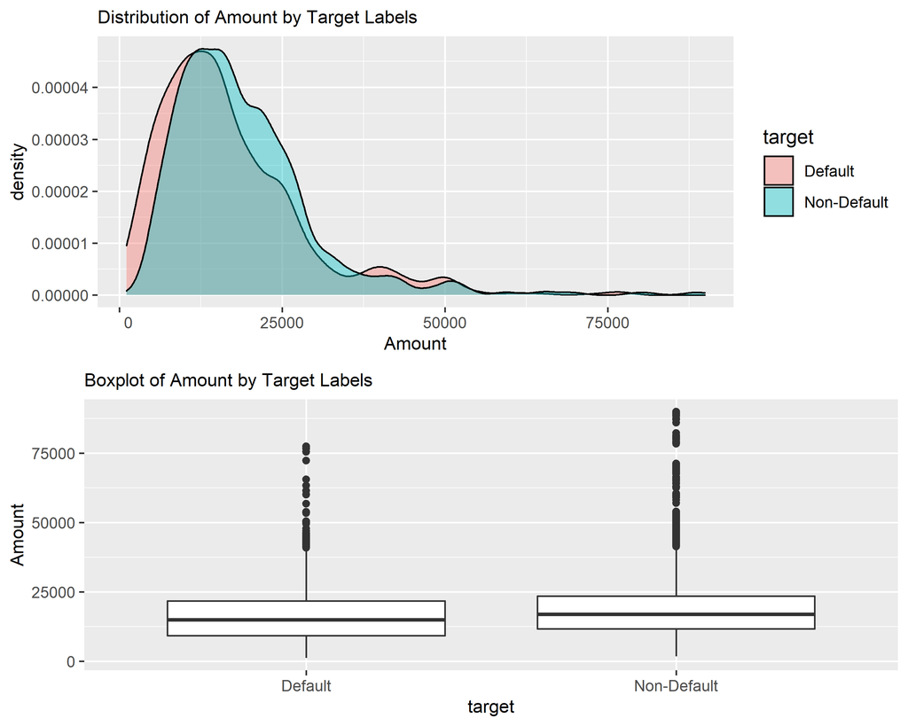

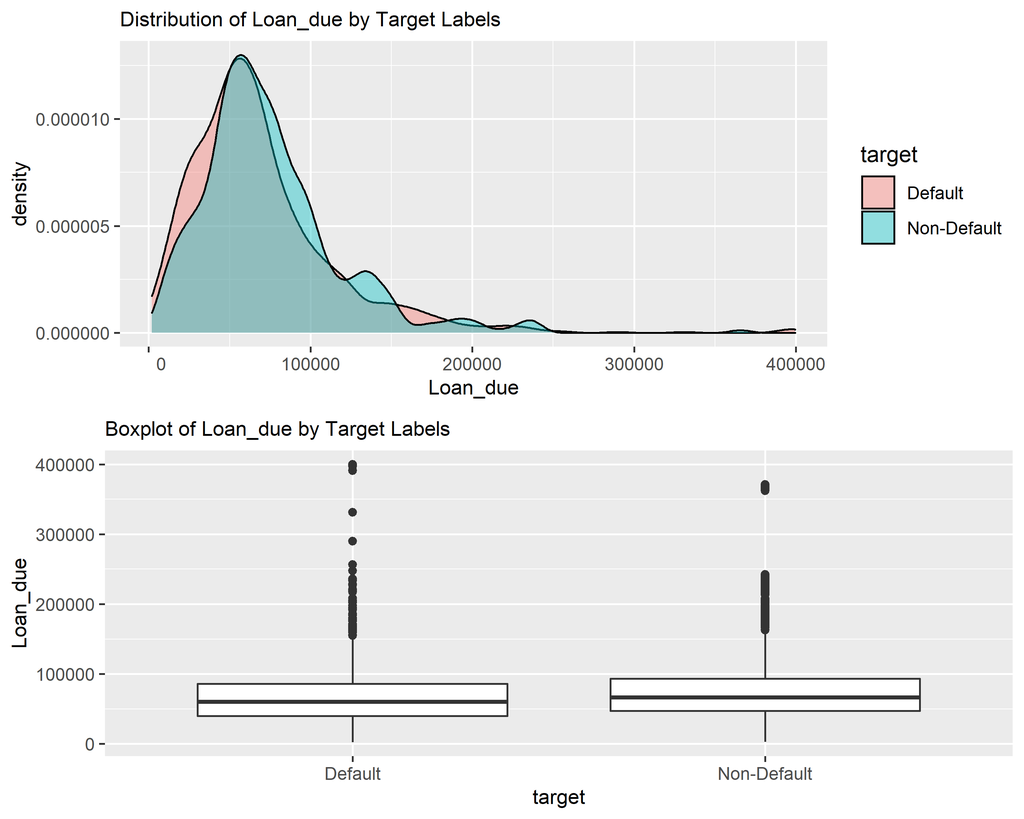

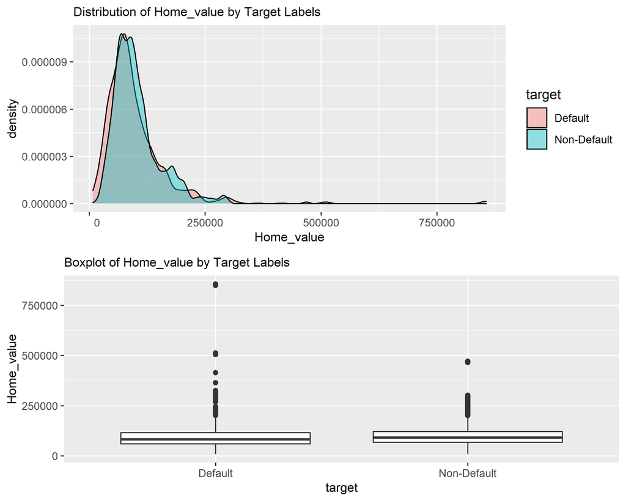

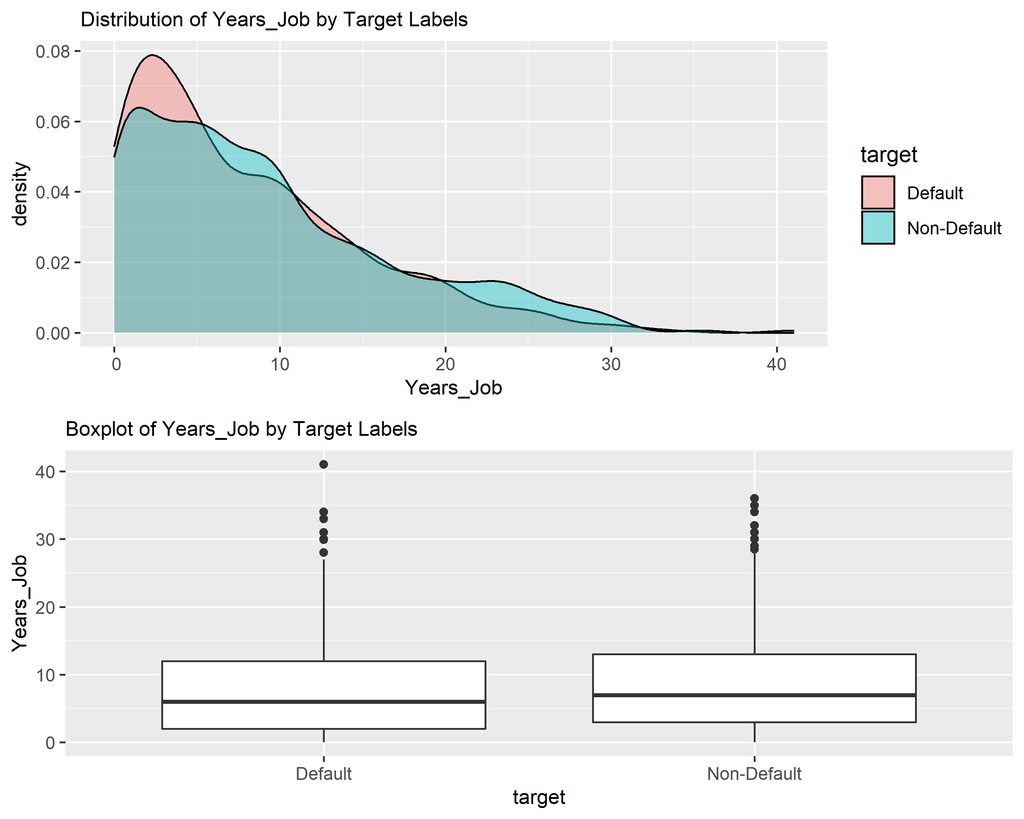

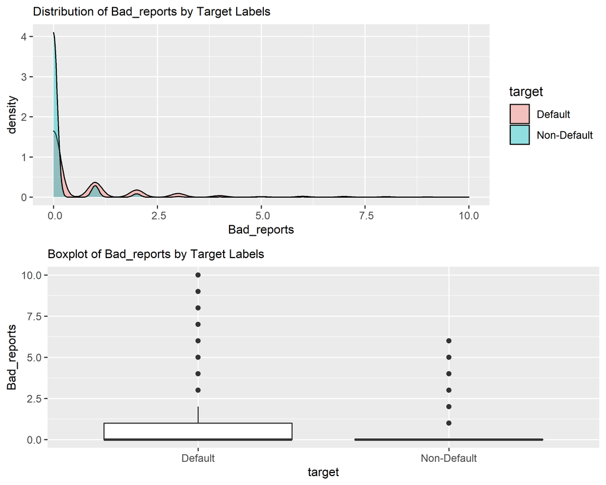

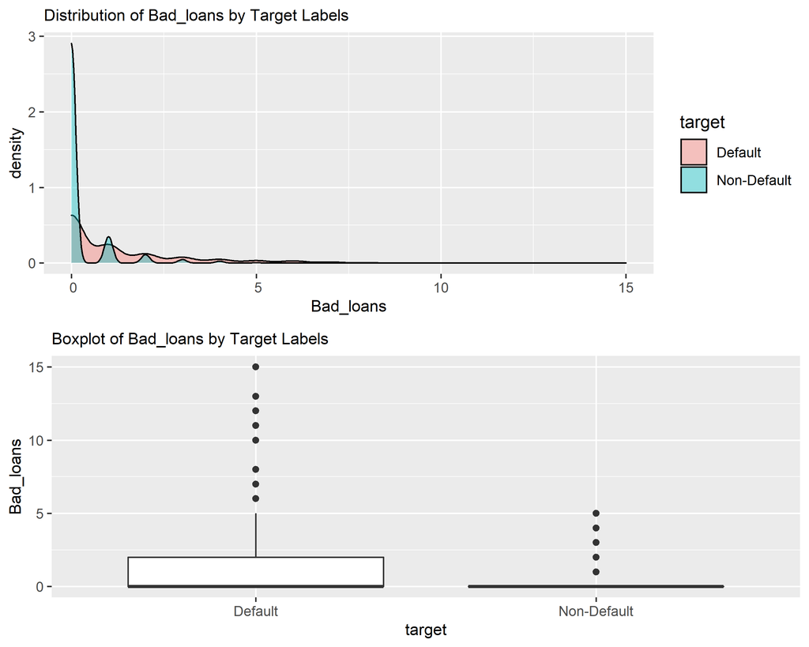

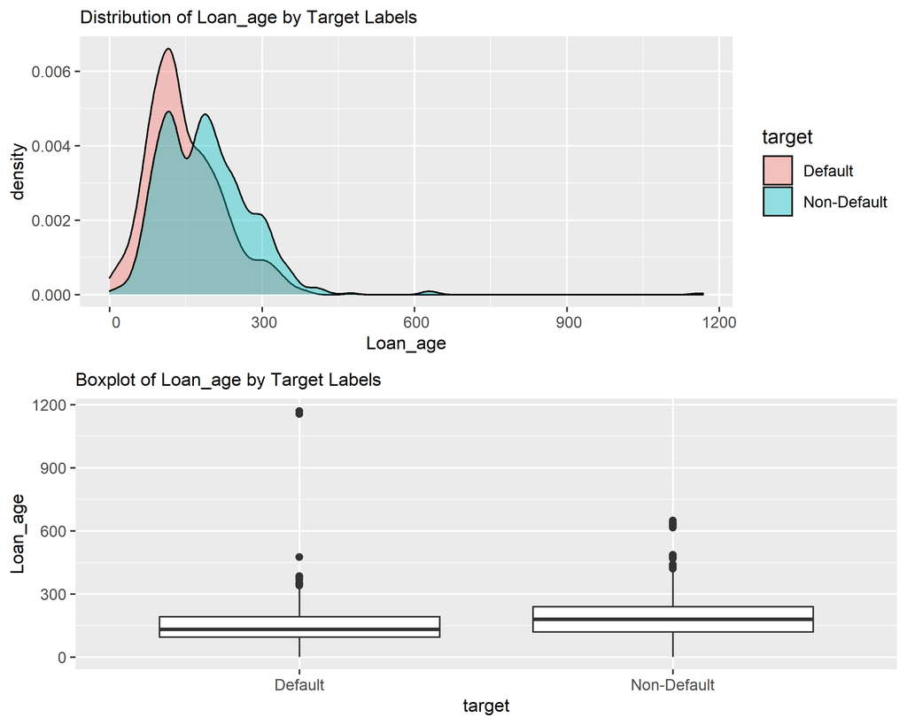

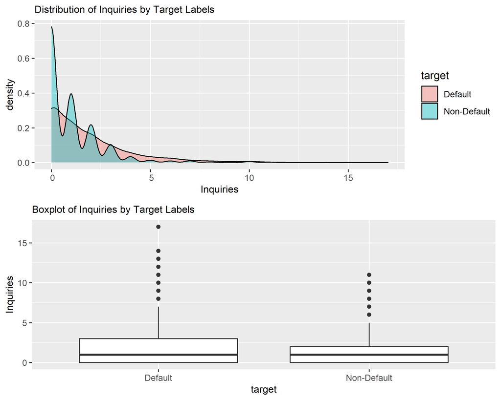

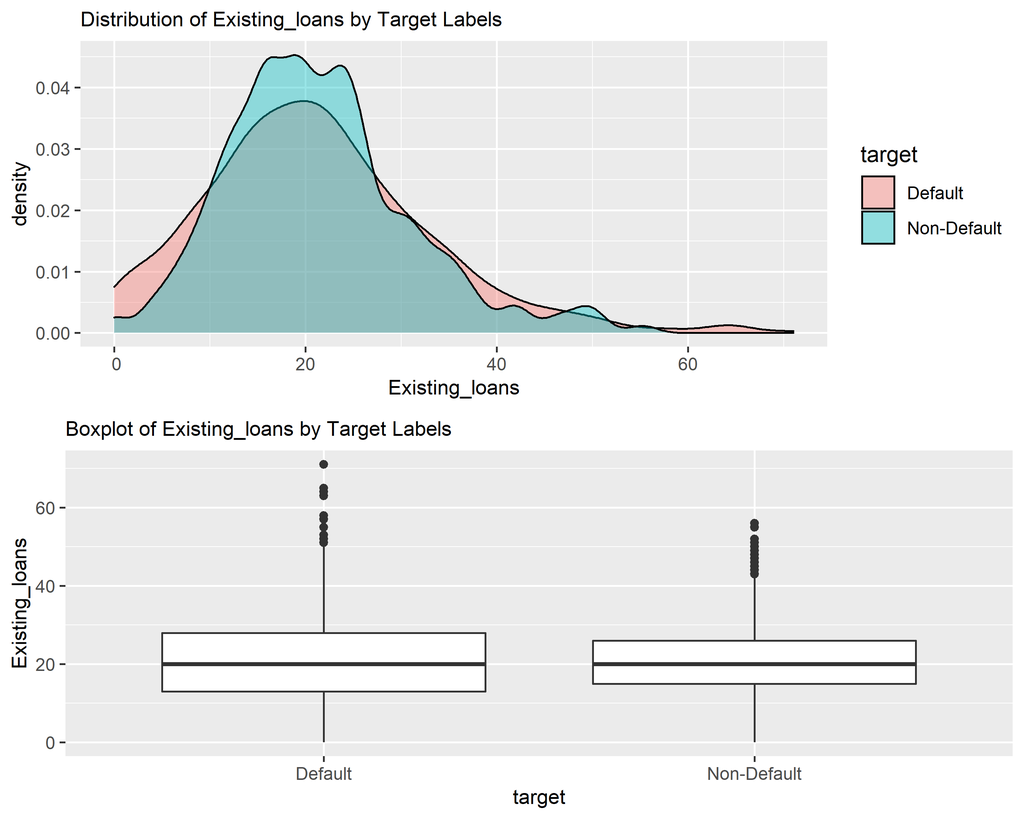

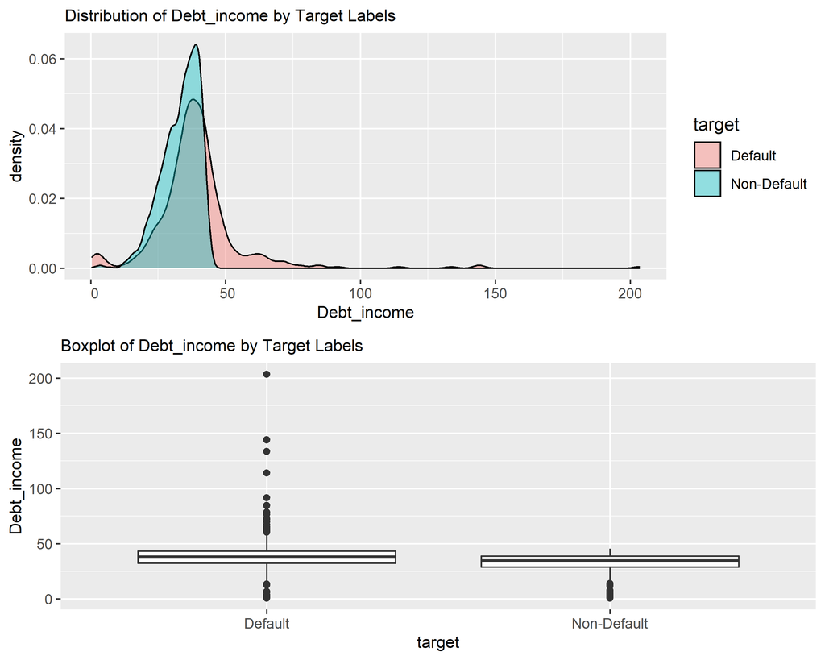

##### We now split the data into train and test sets with stratified partitions of the target variable where the train set has 70 percent rows and the test set has 30 percent rows.

##### The class imbalance ratio in train set is 19.87 percent, and for test set is 20.13 percent.

We wanted to check the **correlation** between all explanatory attributes which are numeric in nature, however due to presence of missing observations we first decided to impute all missing instances with zero; just to get an overview of the business. In our subsequent steps we would implement relatively more robust imputations before model training.

#### The correlation plot is as follows:

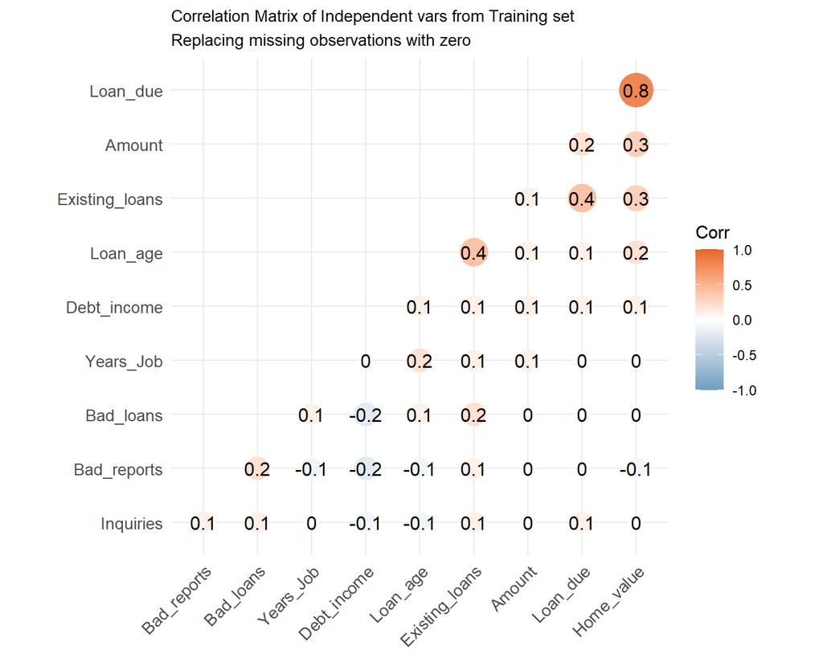

#### The data transformation steps before model training are as follows:

- We have used **dummyvars()** function from **caret** package to convert nominal attributes like Reason and Job into full set dummy variables. It is similar to One-Hot-Encoding
- We have used **bagImpute** and **range** methods from the **preProcess()** function of caret package to impute missing observations and scale the data ranging between 0 and 1
- We have created the transformer first, **trained** the transformer on the training set and then applied the trained transformer on the test set
- The intent of performing the above transformations is to ensure **applicability** of other algorithms apart from logit/probit
- Although it is not customary to perform these steps prior logit/probit, yet to facilitate the **performance** of **test** data on a common refined set of features are not negligible
- However, an obvious disadvantage to this transformation is to restrict the **interpretation** of odds ratios based on the model coefficients in its absolute sense

### Logit Model

#### The summary of three iterations using logit model is as follows:

|  | Iteration-1 |  |  | Iteration-2 |  |  | Iteration-3 |  |  |
| --- | --- | --- | --- | --- | --- | --- | --- | --- | --- |
| Coeffcient | Odds Ratios | Conf. Int (95%) | P-Value | Odds Ratios | Conf. Int (95%) | P-Value | Odds Ratios | Conf. Int (95%) | P-Value |
| Intercept | 0.00 | 0.00 – 0.01 | **<0.001** | 0.00 | 0.00 – 0.00 | **<0.001** | 0.00 | 0.00 – 0.00 | **<0.001** |
| Amount (Borrwed) | 0.10 | 0.04 – 0.27 | **<0.001** | 0.08 | 0.03 – 0.21 | **<0.001** | 0.08 | 0.03 – 0.21 | **<0.001** |
| Loan due | 0.02 | 0.00 – 0.15 | **<0.001** | 0.02 | 0.00 – 0.14 | **<0.001** | 0.02 | 0.00 – 0.13 | **<0.001** |
| Home value | 207.91 | 9.82 – 4823.92 | **0.001** | 262.91 | 12.72 – 5962.44 | **<0.001** | 273.25 | 13.22 – 6223.31 | **<0.001** |
| Reason: DebtCon | 0.73 | 0.41 – 1.36 | 0.309 |  |  |  |  |  |  |
| Reason: HomeImp | 0.85 | 0.47 – 1.60 | 0.593 |  |  |  |  |  |  |
| Job: Mgr | 2.66 | 1.29 – 6.03 | **0.012** | 2.49 | 1.24 – 5.55 | **0.017** | 1.85 | 1.30 – 2.63 | **0.001** |
| Job: Office | 1.49 | 0.72 – 3.40 | 0.311 | 1.42 | 0.70 – 3.18 | 0.364 |  |  |  |
| Job: Other | 2.84 | 1.43 – 6.28 | **0.005** | 2.66 | 1.37 – 5.78 | **0.007** | 1.97 | 1.49 – 2.63 | **<0.001** |
| Job: ProfExe | 3.10 | 1.52 – 7.02 | **0.003** | 2.92 | 1.47 – 6.48 | **0.004** | 2.17 | 1.55 – 3.05 | **<0.001** |
| Job: Sales | 4.78 | 1.92 – 12.62 | **0.001** | 4.36 | 1.79 – 11.26 | **0.002** | 3.23 | 1.69 – 6.05 | **<0.001** |
| Job: Self | 3.45 | 1.40 – 9.04 | **0.009** | 3.45 | 1.42 – 8.85 | **0.008** | 2.55 | 1.35 – 4.70 | **0.003** |
| Years in Job | 0.81 | 0.45 – 1.44 | 0.477 |  |  |  |  |  |  |
| Bad reports | 428.89 | 124.82 – 1544.22 | **<0.001** | 442.13 | 129.50 – 1584.55 | **<0.001** | 435.90 | 127.44 – 1565.71 | **<0.001** |
| Bad loans | 437737.01 | 95579.02 – 2119516.83 | **<0.001** | 452476.55 | 99019.47 – 2185337.50 | **<0.001** | 474288.80 | 103890.89 – 2287768.10 | **<0.001** |
| Loan age | 0.00 | 0.00 – 0.02 | **<0.001** | 0.00 | 0.00 – 0.02 | **<0.001** | 0.00 | 0.00 – 0.02 | **<0.001** |
| Inquiries | 12.04 | 5.04 – 28.84 | **<0.001** | 11.50 | 4.86 – 27.22 | **<0.001** | 11.54 | 4.88 – 27.35 | **<0.001** |
| Existing loans | 0.13 | 0.06 – 0.29 | **<0.001** | 0.12 | 0.06 – 0.27 | **<0.001** | 0.12 | 0.06 – 0.27 | **<0.001** |
| Debt income | 1187796264.85 | 86890226.57 – 18101730863.09 | **<0.001** | 1291452246.20 | 94843485.06 – 19582298628.01 | **<0.001** | 1444881270.94 | 107044527.76 – 21731801686.44 | **<0.001** |
| Observations | 4172 |  |  | 4172 |  |  | 4172 |  |  |
| R<sup>2</sup> Tjur | 0.349 |  |  | 0.349 |  |  | 0.349 |  |  |

#### The iteration sequence is as follows:

- The **null** **deviance** for the model is 4160.34
- Iteration-1 : Model AIC is 2891.75 and Model Deviance is 2853.75
  - Full Model consisting of all explanatory attributes
- Iteration-2 : Model AIC is 2888.69 and Model Deviance is 2856.69
  - **Removed** Reason: DebtCon, Reason: HomeImp and Years in Job
- Iteration-3 : Model AIC is 2887.56 and Model Deviance is 2857.56
  - **Removed** Job: Office

**Odds** **ratio** is evaluated by taking the **exponential** of beta coefficients coming from the logit model.Lets assume that the odds ratio for Loan age is **1.08**. This implies that for **one*** unit** **increase** in the **age** of **loan**, the **odds** of being a **loan** **defaulter** **increases** **multiplicative** by **1.08**. In other words, with one unit increase in age of loan, the **odds** of **default** rises by **0.08** **approximately**. Unfortunately we wont be able to apply the absolute values of odds ratio shown in the above table because we have made transformations in the explanatory variables. However the relative magnitude of the odds ratio suggest that **Debt income**, **Bad loans**, **Bad reports** and **Home value** are the most important predictors in the logit model having higher odds ratio of being a loan defaulter.

The **third iteration** of the logit model shows almost all explanatory attributes are significant at 95% confidence interval, except the ones which are removed.

The 95% **confidence interval** of the odds ratio is also shown where the lower bound is perceived as *at* *least* **and** the upper bound is perceived as *at* *most*.

#### The confusion matrix for third and final iteration is as follows:

Confusion Matrix

|  | p=50% 0 | p=50% 1 |
| --- | --- | --- |
| 0 | 1379 | 220 |
| 1 | 49 | 140 |

#### The area under ROC is as follows:

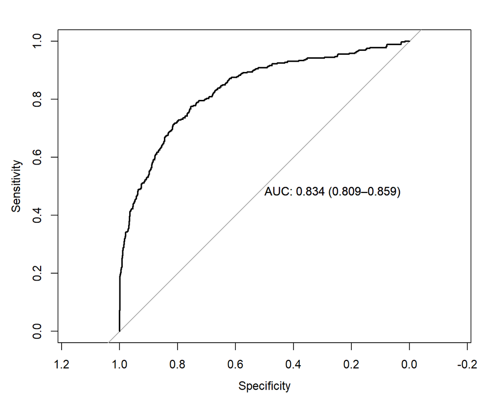

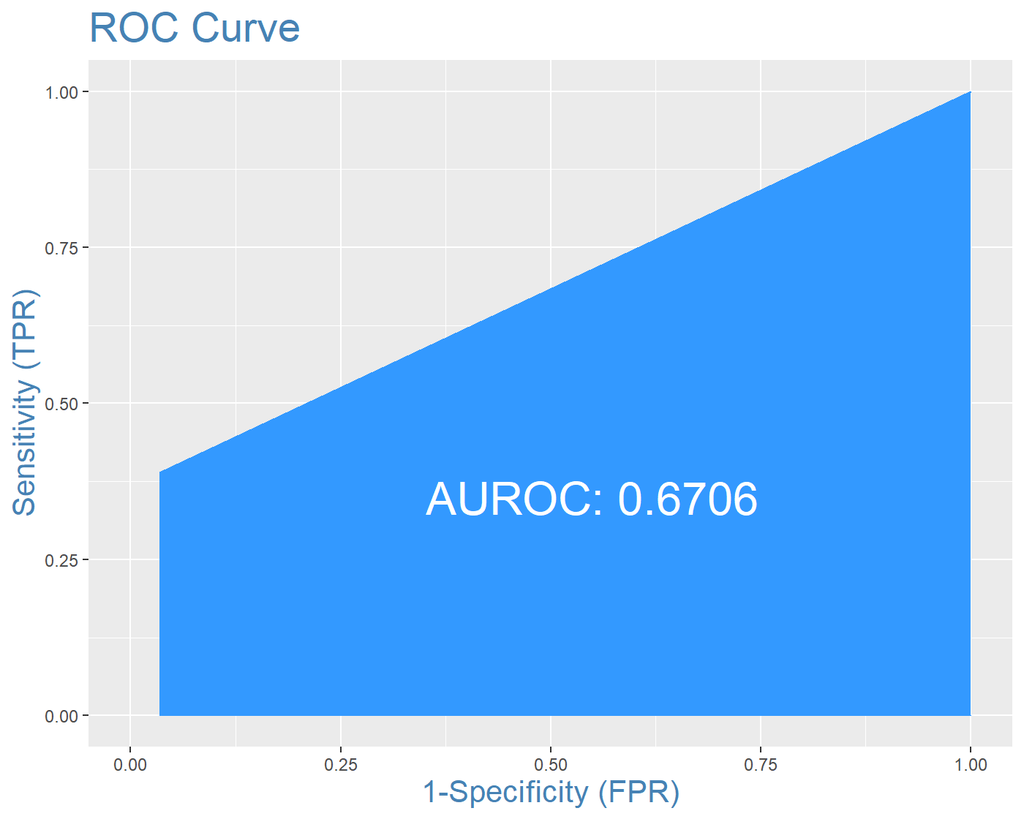

##### The misclassification rate 15.04 percent and the precision is 74.07 percent. However, the ability of the model to correctly identify the defaulters (i.e. Sensitivity) is 38.89 percent and the ability of the model to correctly identify the non defaulters (i.e. Specificity) is 96.57 percent. The somersD value for the logit model is 66.74 percent; larger the Somers D value, better is the model’s predictive ability. The kolmogorov-smirnov statistic for the model is 52.13 percent which is widely used in credit scoring to determine the efficacy of binary classification models.

##### The lift curve for the **Logit** model is as follows:

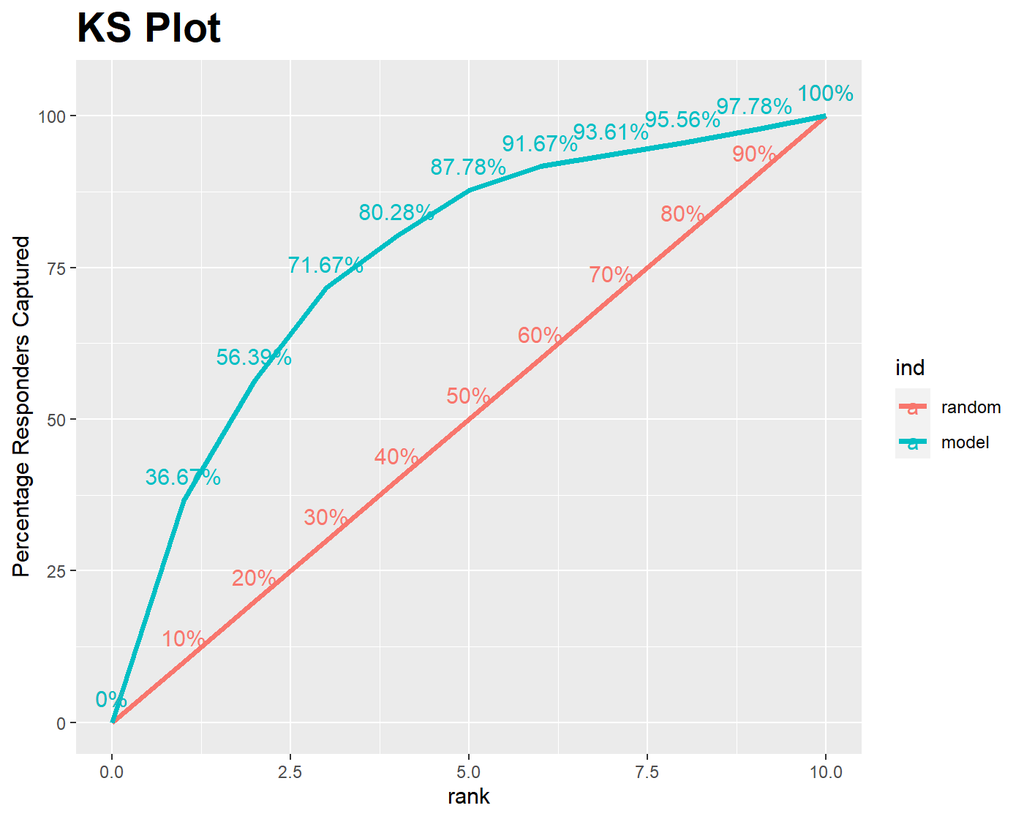

##### The optimal cutoff value for the model is 0.21.

| CUTOFF | FPR | TPR | YOUDENSINDEX | SPECIFICITY | MISCLASSERROR |
| --- | --- | --- | --- | --- | --- |
| 1.00 | 0 | 0.002777778 | 0.0027778 | 1.0000000 | 0.2008 |
| 0.99 | 0 | 0.02777778 | 0.0277778 | 1.0000000 | 0.1957 |
| 0.98 | 0 | 0.04166667 | 0.0416667 | 1.0000000 | 0.1930 |
| 0.97 | 0 | 0.06388889 | 0.0638889 | 1.0000000 | 0.1885 |
| 0.96 | 0.0007002801 | 0.075 | 0.0742997 | 0.9992997 | 0.1868 |
| 0.95 | 0.0007002801 | 0.08611111 | 0.0854108 | 0.9992997 | 0.1846 |
| 0.94 | 0.0007002801 | 0.1 | 0.0992997 | 0.9992997 | 0.1818 |
| 0.93 | 0.0007002801 | 0.1111111 | 0.1104108 | 0.9992997 | 0.1795 |
| 0.92 | 0.0007002801 | 0.1277778 | 0.1270775 | 0.9992997 | 0.1762 |
| 0.91 | 0.0007002801 | 0.1333333 | 0.1326331 | 0.9992997 | 0.1751 |
| 0.90 | 0.0007002801 | 0.1527778 | 0.1520775 | 0.9992997 | 0.1711 |
| 0.89 | 0.00140056 | 0.1555556 | 0.1541550 | 0.9985994 | 0.1711 |
| 0.88 | 0.00140056 | 0.1666667 | 0.1652661 | 0.9985994 | 0.1689 |
| 0.87 | 0.00140056 | 0.1666667 | 0.1652661 | 0.9985994 | 0.1689 |
| 0.86 | 0.00140056 | 0.175 | 0.1735994 | 0.9985994 | 0.1672 |
| 0.85 | 0.00140056 | 0.1805556 | 0.1791550 | 0.9985994 | 0.1661 |
| 0.84 | 0.00140056 | 0.1833333 | 0.1819328 | 0.9985994 | 0.1655 |
| 0.83 | 0.00140056 | 0.1888889 | 0.1874883 | 0.9985994 | 0.1644 |
| 0.82 | 0.00210084 | 0.1972222 | 0.1951214 | 0.9978992 | 0.1633 |
| 0.81 | 0.00280112 | 0.2 | 0.1971989 | 0.9971989 | 0.1633 |
| 0.80 | 0.00280112 | 0.2027778 | 0.1999767 | 0.9971989 | 0.1628 |
| 0.79 | 0.004901961 | 0.2055556 | 0.2006536 | 0.9950980 | 0.1639 |
| 0.78 | 0.004901961 | 0.2138889 | 0.2089869 | 0.9950980 | 0.1622 |
| 0.77 | 0.006302521 | 0.2166667 | 0.2103641 | 0.9936975 | 0.1628 |
| 0.76 | 0.007703081 | 0.2222222 | 0.2145191 | 0.9922969 | 0.1628 |
| 0.75 | 0.008403361 | 0.2277778 | 0.2193744 | 0.9915966 | 0.1622 |
| 0.74 | 0.008403361 | 0.2388889 | 0.2304855 | 0.9915966 | 0.1600 |
| 0.73 | 0.008403361 | 0.2444444 | 0.2360411 | 0.9915966 | 0.1588 |
| 0.72 | 0.008403361 | 0.2472222 | 0.2388189 | 0.9915966 | 0.1583 |
| 0.71 | 0.008403361 | 0.25 | 0.2415966 | 0.9915966 | 0.1577 |

[output cut: 70 more lines]

### Probit Model

#### The summary of three iterations using probit model is as follows:

|  | Iteration-1 |  |  | Iteration-2 |  |  | Iteration-3 |  |  |
| --- | --- | --- | --- | --- | --- | --- | --- | --- | --- |
| Coeffcient | Risk Ratios | Conf. Int (95%) | P-Value | Risk Ratios | Conf. Int (95%) | P-Value | Risk Ratios | Conf. Int (95%) | P-Value |
| Intercept | 0.04 | 0.02 – 0.06 | **<0.001** | 0.04 | 0.02 – 0.05 | **<0.001** | 0.04 | 0.03 – 0.06 | **<0.001** |
| Amount (Borrwed) | 0.33 | 0.19 – 0.54 | **<0.001** | 0.29 | 0.18 – 0.48 | **<0.001** | 0.29 | 0.18 – 0.48 | **<0.001** |
| Loan due | 0.15 | 0.05 – 0.44 | **0.001** | 0.15 | 0.05 – 0.44 | **0.001** | 0.15 | 0.05 – 0.44 | **0.001** |
| Home value | 13.66 | 2.59 – 78.70 | **0.002** | 14.61 | 2.80 – 83.04 | **0.002** | 14.83 | 2.84 – 84.44 | **0.002** |
| Reason: DebtCon | 0.83 | 0.61 – 1.14 | 0.232 |  |  |  |  |  |  |
| Reason: HomeImp | 0.89 | 0.65 – 1.24 | 0.489 |  |  |  |  |  |  |
| Job: Mgr | 1.71 | 1.17 – 2.57 | **0.006** | 1.61 | 1.12 – 2.38 | **0.011** | 1.37 | 1.14 – 1.66 | **0.001** |
| Job: Office | 1.27 | 0.87 – 1.91 | 0.230 | 1.21 | 0.84 – 1.79 | 0.319 |  |  |  |
| Job: Other | 1.82 | 1.28 – 2.70 | **0.001** | 1.73 | 1.23 – 2.52 | **0.002** | 1.48 | 1.27 – 1.72 | **<0.001** |
| Job: ProfExe | 1.85 | 1.28 – 2.77 | **0.001** | 1.76 | 1.23 – 2.59 | **0.002** | 1.50 | 1.25 – 1.80 | **<0.001** |
| Job: Sales | 2.53 | 1.55 – 4.21 | **<0.001** | 2.37 | 1.47 – 3.89 | **<0.001** | 2.02 | 1.41 – 2.89 | **<0.001** |
| Job: Self | 2.14 | 1.34 – 3.49 | **0.001** | 2.11 | 1.34 – 3.39 | **0.001** | 1.80 | 1.29 – 2.50 | **<0.001** |
| Years in Job | 0.82 | 0.60 – 1.12 | 0.217 |  |  |  |  |  |  |
| Bad reports | 36.76 | 18.08 – 76.13 | **<0.001** | 37.50 | 18.51 – 77.39 | **<0.001** | 37.20 | 18.35 – 76.85 | **<0.001** |
| Bad loans | 1761.17 | 774.84 – 4082.69 | **<0.001** | 1799.25 | 792.20 – 4166.52 | **<0.001** | 1831.87 | 806.63 – 4241.13 | **<0.001** |
| Loan age | 0.10 | 0.04 – 0.20 | **<0.001** | 0.09 | 0.04 – 0.20 | **<0.001** | 0.09 | 0.04 – 0.20 | **<0.001** |
| Inquiries | 4.57 | 2.81 – 7.45 | **<0.001** | 4.57 | 2.82 – 7.41 | **<0.001** | 4.55 | 2.80 – 7.38 | **<0.001** |
| Existing loans | 0.31 | 0.20 – 0.46 | **<0.001** | 0.29 | 0.19 – 0.44 | **<0.001** | 0.29 | 0.19 – 0.44 | **<0.001** |
| Debt income | 24775.99 | 7302.93 – 86062.03 | **<0.001** | 24733.19 | 7332.04 – 85397.57 | **<0.001** | 26713.63 | 7980.21 – 91508.87 | **<0.001** |
| Observations | 4172 |  |  | 4172 |  |  | 4172 |  |  |
| R<sup>2</sup> Nagelkerke | 0.420 |  |  | 0.418 |  |  | 0.418 |  |  |

#### The iteration sequence is as follows:

- The **null** **deviance** for the model is 4160.34
- Iteration-1 : Model AIC is 2915.06 and Model Deviance is 2877.06
  - Full Model consisting of all explanatory attributes
- Iteration-2 : Model AIC is 2913.31 and Model Deviance is 2881.31
  - **Removed** Reason: DebtCon, Reason: HomeImp and Years in Job
- Iteration-3 : Model AIC is 2912.32 and Model Deviance is 2882.32
  - **Removed** Job: Office

In the probit model, the inverse standard normal distribution of the probability is modeled as a linear combination of the explanatory attributes. Lets us assume the Risk ratio of Bad Loans is 20. For a one unit increase in Bad Loans, the **z-score** increases/decreases by the value of risk ratio depending upon whether the sign of the coefficient is positive/negative respectively. While this structure holds true for numeric attributes, we may need to interpret the dummy variables differently. Let us assume the risk ratio for Job: Mgr is 2. Having Job level as Manager, **versus a missing Job level** in the data (the reference group), increases the z-score by 2. Unfortunately we wont be able to apply the absolute values of odds ratio shown in the above table because we have made transformations in the explanatory variables. The relative magnitude of the explanatory attributes in probit model suggest similar to logit model that **Debt income**, **Bad loans**, **Bad reports** and **Home value** are the most important predictors in the logit model having higher odds ratio of being a loan defaulter.

#### The confusion matrix for third and final iteration is as follows:

Confusion Matrix

|  | p=50% 0 | p=50% 1 |
| --- | --- | --- |
| 0 | 1376 | 230 |
| 1 | 52 | 130 |

#### The area under ROC is as follows:

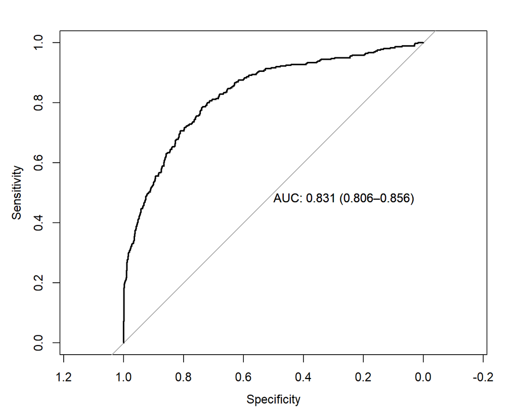

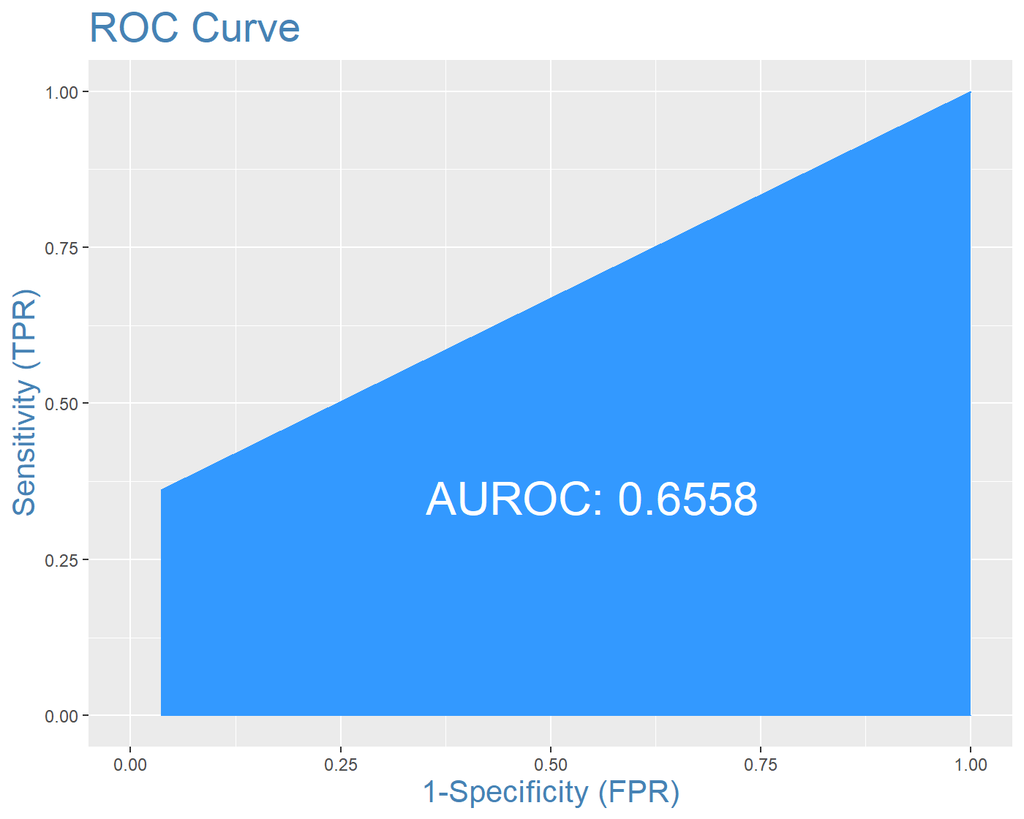

##### The misclassification rate 15.77 percent and the precision is 71.43 percent. However, the ability of the model to correctly identify the defaulters (i.e. Sensitivity) is 36.11 percent and the ability of the model to correctly identify the non defaulters (i.e. Specificity) is 96.36 percent. The somersD value for the probit model is 66.21 percent; larger the Somers D value, better is the model’s predictive ability. The kolmogorov-smirnov statistic for the model is 51.42 percent which is widely used in credit scoring to determine the efficacy of binary classification models.

##### The lift curve for the **Probit** model is as follows:

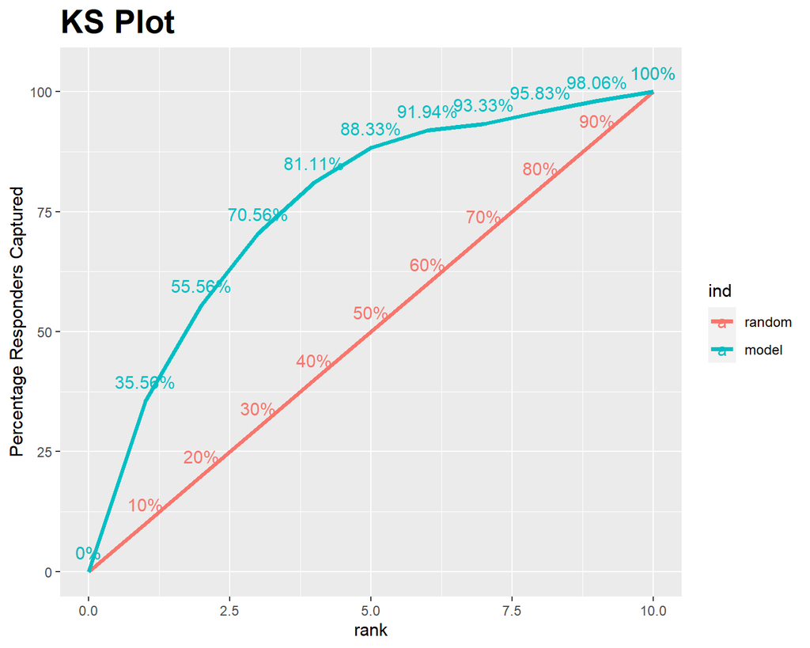

##### The optimal cutoff value for the model is 0.17.

| CUTOFF | FPR | TPR | YOUDENSINDEX | SPECIFICITY | MISCLASSERROR |
| --- | --- | --- | --- | --- | --- |
| 1.00 | 0 | 0.002777778 | 0.0027778 | 1.0000000 | 0.2008 |
| 0.99 | 0 | 0.03611111 | 0.0361111 | 1.0000000 | 0.1941 |
| 0.98 | 0 | 0.05 | 0.0500000 | 1.0000000 | 0.1913 |
| 0.97 | 0 | 0.06666667 | 0.0666667 | 1.0000000 | 0.1879 |
| 0.96 | 0.0007002801 | 0.07222222 | 0.0715219 | 0.9992997 | 0.1874 |
| 0.95 | 0.0007002801 | 0.08888889 | 0.0881886 | 0.9992997 | 0.1840 |
| 0.94 | 0.0007002801 | 0.1027778 | 0.1020775 | 0.9992997 | 0.1812 |
| 0.93 | 0.0007002801 | 0.1111111 | 0.1104108 | 0.9992997 | 0.1795 |
| 0.92 | 0.0007002801 | 0.1166667 | 0.1159664 | 0.9992997 | 0.1784 |
| 0.91 | 0.0007002801 | 0.1277778 | 0.1270775 | 0.9992997 | 0.1762 |
| 0.90 | 0.0007002801 | 0.1277778 | 0.1270775 | 0.9992997 | 0.1762 |
| 0.89 | 0.0007002801 | 0.1277778 | 0.1270775 | 0.9992997 | 0.1762 |
| 0.88 | 0.0007002801 | 0.1361111 | 0.1354108 | 0.9992997 | 0.1745 |
| 0.87 | 0.00140056 | 0.1416667 | 0.1402661 | 0.9985994 | 0.1739 |
| 0.86 | 0.00140056 | 0.1527778 | 0.1513772 | 0.9985994 | 0.1717 |
| 0.85 | 0.00140056 | 0.1583333 | 0.1569328 | 0.9985994 | 0.1706 |
| 0.84 | 0.00140056 | 0.1666667 | 0.1652661 | 0.9985994 | 0.1689 |
| 0.83 | 0.00140056 | 0.1777778 | 0.1763772 | 0.9985994 | 0.1667 |
| 0.82 | 0.00140056 | 0.1833333 | 0.1819328 | 0.9985994 | 0.1655 |
| 0.81 | 0.00210084 | 0.1861111 | 0.1840103 | 0.9978992 | 0.1655 |
| 0.80 | 0.00210084 | 0.1888889 | 0.1867880 | 0.9978992 | 0.1650 |
| 0.79 | 0.00210084 | 0.1972222 | 0.1951214 | 0.9978992 | 0.1633 |
| 0.78 | 0.00280112 | 0.2 | 0.1971989 | 0.9971989 | 0.1633 |
| 0.77 | 0.00280112 | 0.2 | 0.1971989 | 0.9971989 | 0.1633 |
| 0.76 | 0.004901961 | 0.2027778 | 0.1978758 | 0.9950980 | 0.1644 |
| 0.75 | 0.004901961 | 0.2055556 | 0.2006536 | 0.9950980 | 0.1639 |
| 0.74 | 0.007703081 | 0.2083333 | 0.2006303 | 0.9922969 | 0.1655 |
| 0.73 | 0.009103641 | 0.2166667 | 0.2075630 | 0.9908964 | 0.1650 |
| 0.72 | 0.009103641 | 0.2222222 | 0.2131186 | 0.9908964 | 0.1639 |
| 0.71 | 0.009103641 | 0.225 | 0.2158964 | 0.9908964 | 0.1633 |

[output cut: 70 more lines]

#### Comparison and Conclusion:

Diagnostic Measures

| Measures | Logit vs Probit Logit-Model | Logit vs Probit Probit-Model |
| --- | --- | --- |
| Concordance | 0.834 | 0.831 |
| Discordance | 0.166 | 0.169 |
| KS-Stat | 0.521 | 0.514 |
| MisClassification-Error | 0.150 | 0.158 |
| NPV | 0.862 | 0.857 |
| Precision | 0.741 | 0.714 |
| Sensitivity | 0.389 | 0.361 |
| SomersD | 0.667 | 0.662 |
| Specificity | 0.966 | 0.964 |
| Youdens-Index | 0.355 | 0.325 |

###### **There is no drastic difference between both the models and it would be unfair to say that Logit is performing significantly better than Probit model**. Looking at the measures it seems Logit is slightly ahead of Probit, however if we focus minutely on the lift curves of both models we notice the following. In the first 50% of the cases, the logit is able to give 87.78% of defaulters whereas probit is able to give 88.33% of defaulters; which is **0.63%** more.

###### Declaration:-

*The analyst has taken help from recorded video lectures and reading materials provided by Professor Vineet Virmani. The analyst has sought references from cran and R open documentations specific to package tutorials to get specific programming ideas. However, the analyst has not adopted any unfair means or used any readymade GitHub repositories without prior permission to replicate someone else’s work in this project. Any suspicion from the reviewer can be further clarified via discussions or emails*.

[The data for bad loans is also available here](https://github.com/arimitramaiti/datasets/blob/master/articles/bad_loans_data.csv)

Thank You